# Prediction Assignment

Guneet Kalsi

20/06/2020

# Introduction

This report is for Coursera Practical Machine Learning Course’s Final Project. The data is from this source: http://web.archive.org/web/20161224072740/http:/groupware.les.inf.puc-rio.br/har

Basically the data is collected from sensor device such as Jawbone Up, Nike FuelBand, and Fitbit which are attached on belt, forearm, arm, and dumbell of 6 participants. They were asked to perform barbell lifts correctly and incorrectly in 5 different ways.

The objective of this project is to predict the manner in which the participants did the exercise. The variable which I am predicting is called “classe”. Our outcome variable “classe” is a factor variable with 5 levels. For this dataset, “participants were asked to perform one set of 10 repetitions of the Unilateral Dumbbell Biceps Curl in 5 different fashions:

- exactly according to the specification (Class A)
- throwing the elbows to the front (Class B)
- lifting the dumbbell only halfway (Class C)
- lowering the dumbbell only halfway (Class D)
- throwing the hips to the front (Class E)

The report will touch on how the model is built, cross validation, out of sample error and predict the outcome for 20 different test subjects.

# Load Dataset

```r
train <- read.csv("https://d396qusza40orc.cloudfront.net/predmachlearn/pml-training.csv", header=TRUE, stringsAsFactors = TRUE, na.strings = c("","NA"))
test <- read.csv("https://d396qusza40orc.cloudfront.net/predmachlearn/pml-testing.csv", header=TRUE, stringsAsFactors = TRUE, na.strings = c("","NA"))
```

# Data Exploration

```r
library(caret)
library(rattle)
library(randomForest)
```

```r
library(MASS)
library(ggplot2)
library(e1071)
library(gbm)
summary(train)
```

[output not shown]

[output cut: 281 more lines]

```
##  Min.   : -7.02000   Min.   : -8.0900   Min.   :-498.00   Min.   :-632.0
##  1st Qu.: -1.46000   1st Qu.: -0.1800   1st Qu.:-178.00   1st Qu.:  57.0
##  Median :  0.03000   Median :  0.0800   Median : -57.00   Median : 201.0
##  Mean   :  0.07517   Mean   :  0.1512   Mean   : -61.65   Mean   : 163.7
##  3rd Qu.:  1.62000   3rd Qu.:  0.4900   3rd Qu.:  76.00   3rd Qu.: 312.0
##  Max.   :311.00000   Max.   :231.0000   Max.   : 477.00   Max.   : 923.0
##
##  accel_forearm_z   magnet_forearm_x  magnet_forearm_y magnet_forearm_z classe
##  Min.   :-446.00   Min.   :-1280.0   Min.   :-896.0   Min.   :-973.0   A:5580
##  1st Qu.:-182.00   1st Qu.: -616.0   1st Qu.:   2.0   1st Qu.: 191.0   B:3797
##  Median : -39.00   Median : -378.0   Median : 591.0   Median : 511.0   C:3422
##  Mean   : -55.29   Mean   : -312.6   Mean   : 380.1   Mean   : 393.6   D:3216
##  3rd Qu.:  26.00   3rd Qu.:  -73.0   3rd Qu.: 737.0   3rd Qu.: 653.0   E:3607
##  Max.   : 291.00   Max.   :  672.0   Max.   :1480.0   Max.   :1090.0
##
```

```r
head(train)
```

```
##   X user_name raw_timestamp_part_1 raw_timestamp_part_2   cvtd_timestamp
## 1 1  carlitos           1323084231               788290 05/12/2011 11:23
## 2 2  carlitos           1323084231               808298 05/12/2011 11:23
## 3 3  carlitos           1323084231               820366 05/12/2011 11:23
## 4 4  carlitos           1323084232               120339 05/12/2011 11:23
## 5 5  carlitos           1323084232               196328 05/12/2011 11:23
## 6 6  carlitos           1323084232               304277 05/12/2011 11:23
##   new_window num_window roll_belt pitch_belt yaw_belt total_accel_belt
## 1         no         11      1.41       8.07    -94.4                3
## 2         no         11      1.41       8.07    -94.4                3
## 3         no         11      1.42       8.07    -94.4                3
## 4         no         12      1.48       8.05    -94.4                3
## 5         no         12      1.48       8.07    -94.4                3
## 6         no         12      1.45       8.06    -94.4                3
##   kurtosis_roll_belt kurtosis_picth_belt kurtosis_yaw_belt skewness_roll_belt
```

[output cut: 251 more lines]

```r
summary(test)
```

[output not shown]

[output cut: 273 more lines]

```
##  Min.   :-282.0   Min.   :-714.0   Min.   :-787.0   Min.   :-32.0
##  1st Qu.:-199.0   1st Qu.:-427.2   1st Qu.:-328.8   1st Qu.:275.2
##  Median :-148.5   Median :-189.5   Median : 487.0   Median :491.5
##  Mean   : -93.7   Mean   :-159.2   Mean   : 191.8   Mean   :460.2
##  3rd Qu.: -31.0   3rd Qu.:  41.5   3rd Qu.: 720.8   3rd Qu.:661.5
##  Max.   : 179.0   Max.   : 532.0   Max.   : 800.0   Max.   :884.0
##
##    problem_id
##  Min.   : 1.00
##  1st Qu.: 5.75
##  Median :10.50
##  Mean   :10.50
##  3rd Qu.:15.25
##  Max.   :20.00
##
```

```r
head(test)
```

```
##   X user_name raw_timestamp_part_1 raw_timestamp_part_2   cvtd_timestamp
## 1 1     pedro           1323095002               868349 05/12/2011 14:23
## 2 2    jeremy           1322673067               778725 30/11/2011 17:11
## 3 3    jeremy           1322673075               342967 30/11/2011 17:11
## 4 4    adelmo           1322832789               560311 02/12/2011 13:33
## 5 5    eurico           1322489635               814776 28/11/2011 14:13
## 6 6    jeremy           1322673149               510661 30/11/2011 17:12
##   new_window num_window roll_belt pitch_belt yaw_belt total_accel_belt
## 1         no         74    123.00      27.00    -4.75               20
## 2         no        431      1.02       4.87   -88.90                4
## 3         no        439      0.87       1.82   -88.50                5
## 4         no        194    125.00     -41.60   162.00               17
## 5         no        235      1.35       3.33   -88.60                3
## 6         no        504     -5.92       1.59   -87.70                4
##   kurtosis_roll_belt kurtosis_picth_belt kurtosis_yaw_belt skewness_roll_belt
```

[output cut: 251 more lines]

# Data Cleaning

```r
train2 <- train[ , apply(train, 2, function(x) !any(is.na(x)))]
train2 <- train2[,8:60]
```

```r
IndexTrain <- createDataPartition(y=train2$classe, p=0.6, list=FALSE)
training <- train2[IndexTrain,]
testing <- train2[-IndexTrain,]
```

# Model Building

## Decision Tree

Using the train function in the caret package, we set method=“rpart” and train the Decision Tree model with the training data.

```r
tree1 <- train(classe~., method="rpart", data=training)
tree1$finalModel
```

```
## n= 11776
##
## node), split, n, loss, yval, (yprob)
##       * denotes terminal node
##
##  1) root 11776 8428 A (0.28 0.19 0.17 0.16 0.18)
##    2) roll_belt< 130.5 10778 7441 A (0.31 0.21 0.19 0.18 0.11)
##      4) pitch_forearm< -33.05 969   11 A (0.99 0.011 0 0 0) *
##      5) pitch_forearm>=-33.05 9809 7430 A (0.24 0.23 0.21 0.2 0.12)
##       10) magnet_dumbbell_y< 439.5 8328 5995 A (0.28 0.18 0.24 0.19 0.11)
##         20) roll_forearm< 123.5 5216 3128 A (0.4 0.18 0.19 0.17 0.062) *
##         21) roll_forearm>=123.5 3112 2099 C (0.079 0.18 0.33 0.23 0.18) *
##       11) magnet_dumbbell_y>=439.5 1481  728 B (0.031 0.51 0.047 0.22 0.19) *
##    3) roll_belt>=130.5 998   11 E (0.011 0 0 0 0.99) *
```

[figure not shown]

```r
fancyRpartPlot(tree1$finalModel, tweak=1.5)
```

```r
tree.pred <- predict(tree1, newdata = testing)
tree.confuse <- confusionMatrix(tree.pred, testing$classe)
tree.confuse
```

```
## Confusion Matrix and Statistics
##
##           Reference
## Prediction    A    B    C    D    E
##          A 2040  626  615  574  200
##          B   35  533   39  237  204
##          C  154  359  714  475  394
##          D    0    0    0    0    0
##          E    3    0    0    0  644
##
## Overall Statistics
##
##                Accuracy : 0.501
##                  95% CI : (0.4899, 0.5121)
##     No Information Rate : 0.2845
##     P-Value [Acc > NIR] : < 2.2e-16
##
##                   Kappa : 0.3481
##
##  Mcnemar's Test P-Value : NA
##
## Statistics by Class:
##
##                      Class: A Class: B Class: C Class: D Class: E
## Sensitivity            0.9140  0.35112   0.5219   0.0000  0.44660
## Specificity            0.6411  0.91862   0.7867   1.0000  0.99953
## Pos Pred Value         0.5031  0.50859   0.3406      NaN  0.99536
## Neg Pred Value         0.9494  0.85510   0.8863   0.8361  0.88915
## Prevalence             0.2845  0.19347   0.1744   0.1639  0.18379
## Detection Rate         0.2600  0.06793   0.0910   0.0000  0.08208
## Detection Prevalence   0.5168  0.13357   0.2671   0.0000  0.08246
## Balanced Accuracy      0.7775  0.63487   0.6543   0.5000  0.72307
```

## Random Forest

For Random Forest model, manual tuning was done to find the optimal mtry which will be used to train the final model. The optimal mtry will have the lowest out-of-bag error.

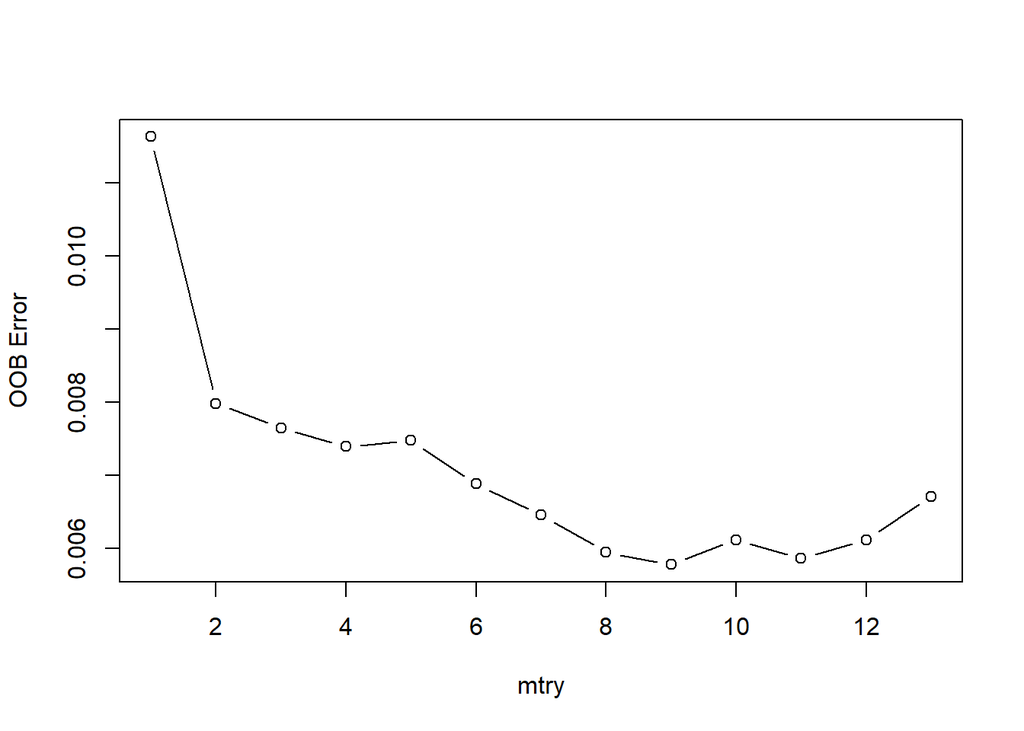

```r
mse.rfs <- rep(0, 13)
for(m in 1:13){
    set.seed(123)
    rf <- randomForest(classe ~ ., data=training, mtry=m)
    mse.rfs[m] <- rf$err.rate[500]
}
plot(1:13, mse.rfs, type="b", xlab="mtry", ylab="OOB Error")
```

```r
mse.rfs
```

```
##  [1] 0.011633832 0.007982337 0.007642663 0.007387908 0.007472826 0.006878397
##  [7] 0.006453804 0.005944293 0.005774457 0.006114130 0.005859375 0.006114130
## [13] 0.006708560
```

```r
optimal.mtry <- which.min(mse.rfs)
rf1 <- randomForest(classe~., data=training, mtry=optimal.mtry)
rf1
```

```
##
## Call:
##  randomForest(formula = classe ~ ., data = training, mtry = optimal.mtry)
##                Type of random forest: classification
##                      Number of trees: 500
## No. of variables tried at each split: 9
##
##         OOB estimate of  error rate: 0.64%
## Confusion matrix:
##      A    B    C    D    E class.error
## A 3344    3    1    0    0 0.001194743
## B   11 2264    4    0    0 0.006581834
## C    0   15 2035    4    0 0.009250243
## D    0    0   26 1902    2 0.014507772
## E    0    0    3    6 2156 0.004157044
```

```r
rf.pred <- predict(rf1, newdata = testing)
rf.confuse <- confusionMatrix(rf.pred, testing$classe)
rf.confuse
```

```
## Confusion Matrix and Statistics
##
##           Reference
## Prediction    A    B    C    D    E
##          A 2229    5    0    0    0
##          B    2 1510   12    0    0
##          C    0    3 1356   10    0
##          D    0    0    0 1275    0
##          E    1    0    0    1 1442
##
## Overall Statistics
##
##                Accuracy : 0.9957
##                  95% CI : (0.9939, 0.997)
##     No Information Rate : 0.2845
##     P-Value [Acc > NIR] : < 2.2e-16
##
##                   Kappa : 0.9945
##
##  Mcnemar's Test P-Value : NA
##
## Statistics by Class:
##
##                      Class: A Class: B Class: C Class: D Class: E
## Sensitivity            0.9987   0.9947   0.9912   0.9914   1.0000
## Specificity            0.9991   0.9978   0.9980   1.0000   0.9997
## Pos Pred Value         0.9978   0.9908   0.9905   1.0000   0.9986
## Neg Pred Value         0.9995   0.9987   0.9981   0.9983   1.0000
## Prevalence             0.2845   0.1935   0.1744   0.1639   0.1838
## Detection Rate         0.2841   0.1925   0.1728   0.1625   0.1838
## Detection Prevalence   0.2847   0.1942   0.1745   0.1625   0.1840
## Balanced Accuracy      0.9989   0.9963   0.9946   0.9957   0.9998
```

## Gradient Boosting Model

For Gradient Boosting Model, train function in the caret package waas used and set method=“gbm”. Verbose=FALSE is to surpress all the messages.

```r
gbm <- train(classe~., method="gbm", data=training, verbose=FALSE)
gbm$finalModel
```

```
## A gradient boosted model with multinomial loss function.
## 150 iterations were performed.
## There were 52 predictors of which 52 had non-zero influence.
```

```r
gbm.pred <- predict(gbm, newdata = testing)
gbm.confuse <- confusionMatrix(gbm.pred, testing$classe)
gbm.confuse
```

```
## Confusion Matrix and Statistics
##
##           Reference
## Prediction    A    B    C    D    E
##          A 2199   60    0    0    3
##          B   24 1410   38    3    9
##          C    8   48 1313   42   14
##          D    1    0   13 1231   17
##          E    0    0    4   10 1399
##
## Overall Statistics
##
##                Accuracy : 0.9625
##                  95% CI : (0.9581, 0.9666)
##     No Information Rate : 0.2845
##     P-Value [Acc > NIR] : < 2.2e-16
##
##                   Kappa : 0.9526
##
##  Mcnemar's Test P-Value : 8.739e-10
##
## Statistics by Class:
##
##                      Class: A Class: B Class: C Class: D Class: E
## Sensitivity            0.9852   0.9289   0.9598   0.9572   0.9702
## Specificity            0.9888   0.9883   0.9827   0.9953   0.9978
## Pos Pred Value         0.9721   0.9501   0.9214   0.9754   0.9901
## Neg Pred Value         0.9941   0.9830   0.9914   0.9916   0.9933
## Prevalence             0.2845   0.1935   0.1744   0.1639   0.1838
## Detection Rate         0.2803   0.1797   0.1673   0.1569   0.1783
## Detection Prevalence   0.2883   0.1891   0.1816   0.1608   0.1801
## Balanced Accuracy      0.9870   0.9586   0.9713   0.9763   0.9840
```

# Model Selection

Based on the summary table below, we can see the model with best accuracy is the Random Forest Model. This model will be used to predict the final class for the 20 subjects in the test data.

```r
table1 <- data.frame(
Model=c("Random Forest","Gradient Boosting", "Decision Tree"),
Accuracy=c(rf.confuse$overall[[1]],gbm.confuse$overall[[1]],tree.confuse$overall[[1]]),
"ConfInv 95 Lower"=c(rf.confuse$overall[[3]],gbm.confuse$overall[[3]],tree.confuse$overall[[3]]),
"ConfInv 95 Upper"=c(rf.confuse$overall[[4]],gbm.confuse$overall[[4]],tree.confuse$overall[[4]])
 )
table1
```

```
##               Model  Accuracy ConfInv.95.Lower ConfInv.95.Upper
## 1     Random Forest 0.9956666        0.9939497        0.9969972
## 2 Gradient Boosting 0.9625287        0.9580873        0.9666220
## 3     Decision Tree 0.5010196        0.4898937        0.5121448
```

# Test Data Prediction

Applying the trained model from Random Forest, we can get the predicted class as shown below.

```r
predictfinal <- predict(rf1, newdata=test, type="class")
predictfinal
```

```
##  1  2  3  4  5  6  7  8  9 10 11 12 13 14 15 16 17 18 19 20
##  B  A  B  A  A  E  D  B  A  A  B  C  B  A  E  E  A  B  B  B
## Levels: A B C D E
```